# BIOSTAT 830 Problem Set 3 Solutions

zihao wang

zihaowang@umich.edu

2016-12-25

# Bayesian Approach to Latent Class Models

1). Directed acyclic graph:

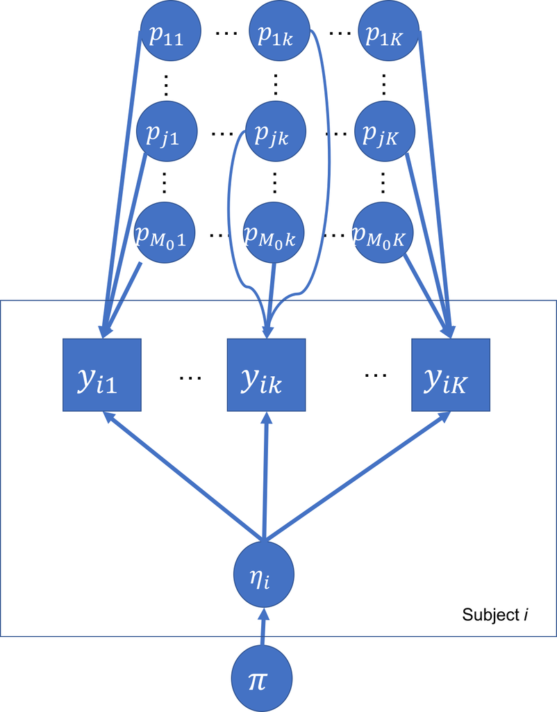

For Subject $i$, the class indicator $\eta_i$ are distributed as a categorical random variable with category probabilities $\boldsymbol{\pi}=(\pi_1, \ldots, \pi_{M_0})'$. Given a realized value of $\eta_i$, say $j$ in a particular observation, the response parameters $\boldsymbol{p}_{j\cdot}=(p_{j1},\ldots, p_{jK})'$ determine the probability of $\{P(Y_{ik}=1\mid \eta_i=j,\boldsymbol{p}_{j\cdot})=p_{jk}\}_{k=1}^K$, one per symptom $k$.

2). $p_{jk}=p_{j+1,k}$, for $j=1,\ldots, M_0-1$. Interpretation: when the depression symptom $k$ does not provide information to distinguish subject $i$ into one of the $M_0$ latent depression classes.

3). Simulate dataset $D^*$

```r
M0 <- 3
K  <- 5
N  <- 300

set.seed(20160901)

p_mat <- matrix(c(0.1,0.9,0.1,0.15,0.1,
                  0.4,0.4,0.45,0.5,0.4,
                  0.95,0.1,0.9,0.9,0.9),nrow=M0,byrow=TRUE)

pi_vec <- c(0.5,0.3,0.2)

dat <- matrix(NA,nrow=N,ncol=K)
eta <- sample(1:M0,size = N,prob = pi_vec,replace = TRUE)
for (i in 1:N){
    for (k in 1:K){
        dat[i,k] <- rbinom(1,1,prob = p_mat[eta[i],k])
      }
}

# tabulate the frequency of each multivariate binary pattern:
pattern_vec <- apply(dat,1,function(v) paste(v,collapse=""))

pattern_table <- matrix(round(table(pattern_vec)/N,3))*100
pattern_table <- cbind(names(table(pattern_vec)),pattern_table)
colnames(pattern_table) <- c("Pattern","Observed Frequency (100%)")

knitr::kable(
  pattern_table, caption = 'Observed frequencies of multivariate binary patterns for $K=5$ depression symptoms (100%)'
)
```

Observed frequencies of multivariate binary patterns for $K=5$ depression symptoms (100%)

| Pattern | Observed Frequency (100%) |
| --- | --- |
| 00000 | 5 |
| 00001 | 1.3 |
| 00010 | 3.3 |
| 00011 | 1.3 |
| 00100 | 2.3 |
| 00101 | 0.7 |
| 00110 | 2 |
| 00111 | 0.7 |
| 01000 | 30.3 |
| 01001 | 1.7 |
| 01010 | 4.7 |
| 01011 | 1 |
| 01100 | 2.7 |
| 01101 | 2 |
| 01110 | 2 |
| 01111 | 0.7 |
| 10000 | 2.7 |
| 10001 | 1.3 |
| 10010 | 2 |
| 10011 | 2 |
| 10100 | 1 |
| 10101 | 3 |
| 10110 | 2.7 |
| 10111 | 16.7 |
| 11000 | 2 |
| 11001 | 1 |
| 11010 | 1.7 |
| 11011 | 0.3 |
| 11100 | 1 |
| 11111 | 1 |

```r
lor_obs <- function(x,y){
    log(sum(x==1 & y==1))+log(sum(x==0 & y==0))-
    log(sum(x==1 & y==0))-log(sum(x==0 & y==1))
}

psi_obs_mat <- matrix(NA,nrow=K,ncol=K)

for (i in 1:K){
  for (j in 1:K){
      if (i!=j){
      psi_obs_mat[i,j] <- lor_obs(dat[,i],dat[,j])
      }
    }
  }

# calculate the observed pairwise log odds ratios:
colnames(psi_obs_mat) <- rownames(psi_obs_mat) <- paste("Symptom",1:K,sep=" ")
knitr::kable(
  round(psi_obs_mat,2), caption = 'Observed pariwise log odds ratios'
)
```

Observed pariwise log odds ratios

|  | Symptom 1 | Symptom 2 | Symptom 3 | Symptom 4 | Symptom 5 |
| --- | --- | --- | --- | --- | --- |
| Symptom 1 | NA | -2.49 | 1.99 | 1.86 | 2.39 |
| Symptom 2 | -2.49 | NA | -1.94 | -1.85 | -2.01 |
| Symptom 3 | 1.99 | -1.94 | NA | 1.73 | 2.23 |
| Symptom 4 | 1.86 | -1.85 | 1.73 | NA | 1.71 |
| Symptom 5 | 2.39 | -2.01 | 2.23 | 1.71 | NA |

4). *Write out the likelihood*

$$\begin{aligned}
L(\boldsymbol{a},\boldsymbol{g}; \boldsymbol{Y}) &
= \prod_{i=1}^N\left\{\sum_{j=1}^{M_{fit}}\frac{\exp(a_j)}{\sum_{\ell=1}^{M_{fit}}\exp(a_\ell)}\prod_{k=1}^K \frac{\exp(g_{jk}Y_{ik})}{1+\exp(g_{jk})}\right\},
\end{aligned}$$
where $a_{M_{fit}}=0$.

5). *Full Conditionals*

The full conditional distributions are useful for designing Gibbs sampling algorithms. In the DAG, we identify the children and parents of the parameter under concern and multiply the conditional distributions that invole both the identified parent or child nodes and the parameter.

1. $$[g_{jk}\mid \{g_{-j,-k}\}, \boldsymbol{\eta}, \boldsymbol{Y}] \propto [\boldsymbol{Y}\mid \boldsymbol{\eta},\boldsymbol{g}][g_{jk}]
   \propto \prod_{i=1}^N\prod_{k=1}^K\prod_{j=1}^{M_{fit}}\left\{\frac{\exp(g_{jk}Y_{ik})}{1+\exp(g_{jk})}\right\}^{\boldsymbol{1}\{\eta_i=j\}}\cdot \exp(-2g_{jk}^2/9)$$

$$[a_j \mid \{a_{-j}\},\boldsymbol{\eta}] \propto [\boldsymbol{\eta}\mid \boldsymbol{a}][a_j]
\propto \prod_{i=1}^N \prod_{j=1}^{M_{fit}} \left\{\frac{\exp(a_j)}{\sum_{j=1}^{M_{fit}}\exp(a_j)}\right\}^{\boldsymbol{1}\{\eta_i=j\}}\cdot \exp(-2a^2_j/9)$$

3. $$[\eta_i \mid \boldsymbol{a},\boldsymbol{g},\boldsymbol{Y}] \propto
   [Y_i \mid \boldsymbol{\eta}, \boldsymbol{g}][\eta_i \mid \boldsymbol{a}]
   \propto \prod_{j=1}^{M_{fit}}\left\{\prod_{k=1}^K\frac{\exp(g_{jk}Y_{ik})}{1+\exp(g_{jk})}\cdot \frac{\exp(a_j)}{\sum_\ell \exp(a_\ell)}\right\}^{\boldsymbol{1}\{\eta_i = j\}}$$